# Algebra and Statistical Methods for Big Data with Bioconductor

# 10 Using algebra procedure for `DelayedMatrix` objects to implement basic statistical methods

## 10.1 Principal component analysis (PCA)

Let us illustrate how to perform a PCA using miRNA data obtained from TCGA corresponding to 3 different tumors: melanoma (ME), leukemia (LEU) and centran nervous system (CNS). Data is available at `BigDataStatMeth` and can be loaded by simply:

```r
data(miRNA)
dim(miRNA)
[1]  21 537
```

We observe that there are a total of 21 individuals and 537 miRNAs. The vector `cancer` contains the type of tumor of each individual. For each type we have:

```r
table(cancer)
cancer
CNS  LE  ME
  6   6   9
```

Now, the typical principal component analysis on the samples can be run on the `miRNA` matrix since it has miRNAs in columns and individuals in rows

```r
pc <- prcomp(miRNA)
```

We can plot the two first components with:

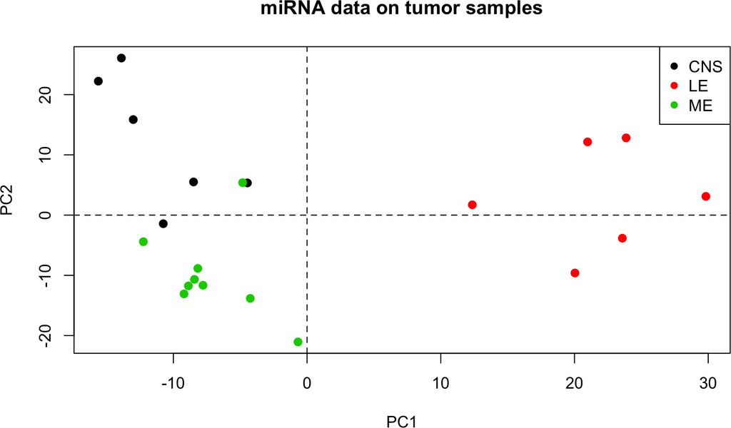

```r
plot(pc$x[, 1], pc$x[, 2],
     main = "miRNA data on tumor samples",
     xlab = "PC1", ylab = "PC2", type="n")
abline(h=0, v=0, lty=2)
points(pc$x[, 1], pc$x[, 2], col = cancer,
       pch=16, cex=1.2)
legend("topright", levels(cancer), pch=16, col=1:3)
```

```r
miRNAD <- DelayedArray(miRNA)
miRNAD.c <- DelayedArray::sweep(miRNAD, 2,
      DelayedArray::colMeans(miRNAD), "-")
svd.da <- bdSVD(miRNAD.c, bcenter = FALSE, bscale = FALSE)
```

The PCA plot for the two principal components can then be be obtained by:

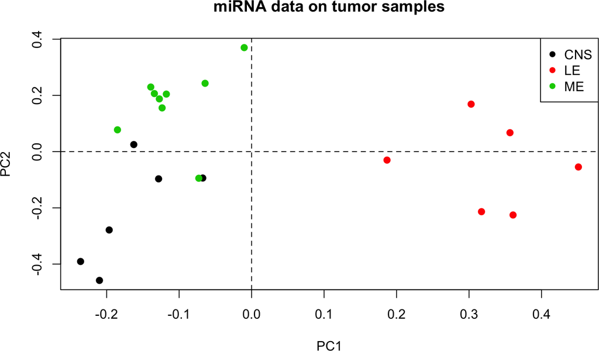

```r
plot(svd.da$u[, 1], svd.da$u[, 2],
     main = "miRNA data on tumor samples",
     xlab = "PC1", ylab = "PC2", type="n")
abline(h=0, v=0, lty=2)
points(svd.da$u[, 1], svd.da$u[, 2], col = cancer,
       pch=16, cex=1.2)
legend("topright", levels(cancer), pch=16, col=1:3)
```

We can observe that both figures are equal irrespective to a sign change of second component (that can happen in SVD).

# 11 Statistical methods implemented for `DelayedMatrix` objects

In this section we illustrate how to estimate some of the state of the art methods used in omic data analyses having a `DelayedMatrix` as the input object. So far, we have implemented the lasso regression, but other methods are going to be implemented in the near future.

## 11.1 Lasso regression

The standard linear model (or the ordinary least squares method) performs poorly in a situation, where you have a large multivariate data set containing a number of variables superior to the number of samples. This is the case, for instance, of genomic, transcriptomic or epigenomic studies where the number of variables (SNPs, genes, CpGs) exceed the number of samples (i.e. transcriptomic analysis deals with ~20,000 genes on hundreds of individuals).

A better alternative is the penalized regression allowing to create a linear regression model that is penalized, for having too many variables in the model, by adding a constraint in the equation. This is also known as shrinkage or regularization methods. Lasso regression is one of the methods which are based on this idea. Lasso stands for Least Absolute Shrinkage and Selection Operator. It shrinks the regression coefficients toward zero by penalizing the regression model with a penalty term called L1-norm, which is the sum of the absolute coefficients.

In the case of lasso regression, the penalty has the effect of forcing some of the coefficient estimates, with a minor contribution to the model, to be exactly equal to zero. This means that, lasso can be also seen as an alternative to the subset selection methods for performing variable selection in order to reduce the complexity of the model, or in other words, the number of variables. Selecting a good value of $\lambda$ is critical.

This tunning parameter can be estimated using cross-validation. However, this procedure can be very time consuming since the inversion of a matrix is highly time consuming and it must be computed for each cross-validated sub-sample. In order to avoid this, we have implemented a method proposed by [Rifkin and Lippert](http://cbcl.mit.edu/publications/ps/MIT-CSAIL-TR-2007-025.pdf) who stated that in the context of regularized least squares, one can search for a good regularization parameter $\lambda$ at essentially no additional cost (i.e. estimating only one inverion matrix).

Let us illustrate how this works in our package. Let us start by simulating a dataset with 200 variables when only 3 of them are associated with the outcome.

```r
# number of samples
n <- 500
# number of variables
p <- 200
# covariates
M <- matrix(rnorm(n*p), nrow=n, ncol=p)
# outcome (only variables 1, 2 and 5 are different from 0)
Y <- 2.4*M[,1] + 1.6*M[,2] - 0.4*M[,5]
```

Then the model can be fitted (using `DelayedMatrix` objects) by

```r
# Get DealyedArray matrices
MD <- DelayedArray(M)
YD <- DelayedArray(as.matrix(Y))

# Model
mod <- LOOE(MD, YD, paral=FALSE)
mod$coef[abs(mod$coef)>mean(mod$coef)]
[1]  2.4021139  1.6004763 -0.3989715
```

The argument `paral` is required to indicate whether paralell implementation is used or not. The `lambda` argument can be provided by the user, but it can also be estimated if `l` parameter is missing:

```r
library(glmnet)
mod.cv <- cv.glmnet(M, Y)
mod.glmnet <- glmnet(M, Y, lambda=mod.cv$lambda.min)
mod.glmnet$beta[1:7,]
        V1         V2         V3         V4         V5         V6         V7
 2.3481950  1.5510646  0.0000000  0.0000000 -0.3517855  0.0000000  0.0000000
```

# 12 Utils for data analysis working directly in hdf5 files

## 12.1 Data imputation

Imputation in genetics refers to the statistical inference of unobserved genotypes. In genetic epidemiology and quantitative genetics, researchers aim at identifying genomic locations where variation between individuals is associated with variation in traits of interest between individuals.

At the moment BigDataStatMeth has implemented snps imputation following the encoding used in Genomic Data Structure file format (GDS files) where SNPs are codded as 0 : two B alleles, 1 : one A allele and one B allele, 2 : two A alleles and 3 : missing data. BigDataStatMeth impute data where SNPs values are ‘3’ (missing data).

The imputation method implemented is generated from the information of the SNP data that contains the missing data, it is performed by generating a random value following a discrete distribution. If in the SNP we find 70% of ‘0’, 25% of ‘1’ and 5% of ‘2’, the value of the missing data will be imputed with a probability of 70% to be ‘0’, 25% to be ‘1’ and 5% to be ‘2’.

We first simulate a genotype matrix with 0, 1, 2 and 3 and store it in hdf5 file and show data stored in file:

```r
set.seed(108432)
geno.sim <- matrix(sample(0:3, 10000, replace = TRUE), byrow = TRUE, ncol = 10)
Create_HDF5_matrix(geno.sim, "delayed.hdf5", "OMICS", "geno")
[1] 0

# Get data and show the first 5 rows
h5fsvd = H5Fopen("delayed.hdf5")
geno <- h5fsvd$OMICS$geno
h5closeAll()

geno[1:5,1:10]
     [,1] [,2] [,3] [,4] [,5] [,6] [,7] [,8] [,9] [,10]
[1,]    0    2    1    3    3    2    3    1    0     3
[2,]    2    3    2    2    1    3    3    0    2     3
[3,]    0    0    1    2    2    1    2    0    0     1
[4,]    2    0    1    1    3    0    1    1    3     3
[5,]    3    0    1    3    3    0    0    1    1     3
```

Remember, we allways have to close hdf5 data file. Now we impute values where genotype = ‘3’ (missing data in GDS format). To apply imputation we only have to indicate the file where dataset is, the group and the dataset name, optionally, we indicate were we want to store results with `outputgroup` and `outputfolder`, by default the results are stored in the input dataset. An important parameter is `bycols`, with `bycols` we can inform if we want to impute data by cols `bycols = TRUE` or by rows `bycols = FALSE`, the default imputation implemented method is by cols.

In next example we perform the imputation in “imputedgeno” dataset inside the group “OMICS” and the imputation method applied takes into account the probabilities in columns (default).

```r
bdImputeSNPHDF5("delayed.hdf5", group="OMICS", dataset="geno",
                outgroup="OMICS", outdataset="imputedgeno")
[1] 0
```

Now we get the imputation results

```r
# Get imputed data and show the first 5 rows
h5fsvd = H5Fopen("delayed.hdf5")
imputedgeno <- h5fsvd$OMICS$imputedgeno
h5closeAll()

imputedgeno[1:5,1:10]
     [,1] [,2] [,3] [,4] [,5] [,6] [,7] [,8] [,9] [,10]
[1,]    0    2    1    2    2    2    1    1    0     0
[2,]    2    0    2    2    1    1    1    0    2     1
[3,]    0    0    1    2    2    1    2    0    0     1
[4,]    2    0    1    1    1    0    1    1    0     0
[5,]    0    0    1    2    2    0    0    1    1     0
```

## 12.2 Normalization, center and scale

Normalization is one of the most important procedures in genomics data analysis. A typical dataset contains more than one sample and we are almost always interested in making comparisons between these and in order to make comparisons we need to normalize data.

In BigDataStatMeth we implemented a normalization method that works directly with datasets stored in hdf5 file format, like in other functions implemented in BigDataSet that works with hdf5 data files, we have to indicate where the data is, the filename, the name of the group under the dataset is and the dataset name. In normalization function, we can indicate if we want to center data, scale or center and scale (default option). The applied formula to normalize data by default in implemented function is :
$$\frac{X - \mu}{\sigma}$$

The implemented function to normalize data directo from hdf5 data file is `Normalize_hdf5`.

To show you an example, we will use the imputed geno dataset *imputedgeno* created before in imputation method example. To normalize data we have to indicate where the dataset is stored and we have two optiona paramters `bcenter` and `bscale` with default value = TRUE. In order to normalize data, we don’t need to modify these optional parameters. If we only want to center data, then we have to put `bscale = FALSE` or if we only want to scale data `bcenter` parameter must be FALSE.

Let show an example normalizing imputed geno under group “OMICS” in delayed.hdf5 file:

```r
Normalize_hdf5("delayed.hdf5", group="OMICS", dataset="imputedgeno")
[1] 0
```

```r
# Geno after normalization
h5fsvd = H5Fopen("delayed.hdf5")
genonormalized <- h5fsvd$NORMALIZED$OMICS$geno
h5closeAll()

genonormalized[1:5,1:10]
NULL
```

[output not shown]

[output not shown]

## 12.3 QC - Remove low data

Missing data in meta-analysis of genetic association studies are unavoidable. In BigDataStatMeth we implemented a function to remove those SNPs with a hight percentage of missing data. The implemented function to remove SNPs wit a certain percentage of missing data is the function `bdRemovelowdata`

Like in imputation method, in remove low data method we have to inform the input data indicating the filename, the group and the dataset name and we also have to inform the dataset were data will be stored after removing the SNPs with parameters `outgroup` and `outdataset`.

To remove low data we have to infrorm if we want to remove data by cols `SNPincols = TRUE` or by rows `SNPincols = FALSE` and the percentage of missing data `pcent` parameter. `pcent` of missing data refers to missing percentage in columns if we defined `SNPincols = TRUE` or `pcent` refers to rows if `SNPincols = FALSE`.

```r
bdRemovelowdata("delayed.hdf5", group="OMICS", dataset="geno",
                outgroup="OMICS", outdataset="removedgeno",
                SNPincols = TRUE, pcent = 0.39)

 Input and output datasets will be different
Warning in evalq((function (..., call. = TRUE, immediate. = FALSE, noBreaks. = FALSE, : -235 Columns have been removed
[1] -235
```

After remove the SNPs with pcent greater than 39% results have been saved in dataset “*removedgeno*” under group “*OMICS*”, we observe the resulting dataset

```r
# Get imputed data and show the first 5 rows
h5fsvd = H5Fopen("delayed.hdf5")
removedgeno <- h5fsvd$OMICS$removedgeno
h5closeAll()

removedgeno[1:5,1:10]
     [,1] [,2] [,3] [,4] [,5] [,6] [,7] [,8] [,9] [,10]
[1,]    0    2    1    3    2    3    1    0    1     2
[2,]    2    3    2    2    3    3    0    2    1     2
[3,]    0    0    1    2    1    2    0    0    1     3
[4,]    2    0    1    1    0    1    1    3    1     1
[5,]    3    0    1    3    0    0    1    1    3     2
```

# 13 References

[1] Fischer, Bernd, Gregoire Pau, and Mike Smith. (2019). R Interface to Hdf5. https://github.com/grimbough/rhdf5

# 14 Session information

```r
sessionInfo()
R version 3.6.3 (2020-02-29)
Platform: x86_64-apple-darwin15.6.0 (64-bit)
Running under: macOS Mojave 10.14.4

Matrix products: default
BLAS:   /Library/Frameworks/R.framework/Versions/3.6/Resources/lib/libRblas.0.dylib
LAPACK: /Library/Frameworks/R.framework/Versions/3.6/Resources/lib/libRlapack.dylib

locale:
[1] ca_ES.UTF-8/ca_ES.UTF-8/ca_ES.UTF-8/C/ca_ES.UTF-8/ca_ES.UTF-8

attached base packages:
[1] parallel  stats4    stats     graphics  grDevices utils     datasets  methods   base

other attached packages:
 [1] glmnet_4.0-2         Matrix_1.2-18        microbenchmark_1.4-7 DT_0.15              rhdf5_2.30.1         DelayedArray_0.12.3  BiocParallel_1.20.1  IRanges_2.20.2
 [9] S4Vectors_0.24.4     BiocGenerics_0.32.0  matrixStats_0.56.0   BigDataStatMeth_1.1  BiocStyle_2.14.4

loaded via a namespace (and not attached):
 [1] Rcpp_1.0.5          mvtnorm_1.1-1       lattice_0.20-41     zoo_1.8-8           foreach_1.5.0       digest_0.6.25       R6_2.4.1            evaluate_0.14
 [9] ggplot2_3.3.2       highr_0.8           pillar_1.4.6        rlang_0.4.7         multcomp_1.4-13     magick_2.4.0        rmarkdown_2.3       splines_3.6.3
[17] stringr_1.4.0       RcppEigen_0.3.3.7.0 htmlwidgets_1.5.1   munsell_0.5.0       beachmat_2.2.1      compiler_3.6.3      xfun_0.16           pkgconfig_2.0.3
[25] shape_1.4.4         htmltools_0.5.0     tidyselect_1.1.0    tibble_3.0.3        bookdown_0.20       codetools_0.2-16    crayon_1.3.4        dplyr_1.0.2
[33] MASS_7.3-52         grid_3.6.3          gtable_0.3.0        lifecycle_0.2.0     magrittr_1.5        scales_1.1.1        RcppParallel_5.0.2  stringi_1.4.6
[41] farver_2.0.3        ellipsis_0.3.1      vctrs_0.3.2         generics_0.0.2      sandwich_2.5-1      TH.data_1.0-10      Rhdf5lib_1.8.0      iterators_1.0.12
[49] tools_3.6.3         glue_1.4.1          purrr_0.3.4         survival_3.2-3      yaml_2.2.1          colorspace_1.4-1    BiocManager_1.30.10 knitr_1.29
```

Fischer, Bernd, Gregoire Pau, and Mike Smith. 2019. *Rhdf5: R Interface to Hdf5*. https://github.com/grimbough/rhdf5.